# automatization_notebook_02

Stanislav Legkovoy

2023-10-14

# Чтение данных

В вашем варианте нужно использовать датасет food.

```r
food <- read.csv("data/raw/food.csv")
```

# Выведите общее описание данных

```r
str(food)
```

```
## 'data.frame':    7083 obs. of  38 variables:
##  $ Category                      : chr  "Milk" "Milk" "Milk" "Milk" ...
##  $ Description                   : chr  "Milk, human" "Milk, NFS" "Milk, whole" "Milk, low sodium, whole" ...
##  $ Nutrient.Data.Bank.Number     : int  11000000 11100000 11111000 11111100 11111150 11111160 11111170 11112110 11112120 11112130 ...
##  $ Data.Alpha.Carotene           : int  0 0 0 0 0 0 0 0 0 0 ...
##  $ Data.Beta.Carotene            : int  7 4 7 7 7 1 0 3 1 3 ...
##  $ Data.Beta.Cryptoxanthin       : int  0 0 0 0 0 0 0 0 0 0 ...
##  $ Data.Carbohydrate             : num  6.89 4.87 4.67 4.46 4.67 5.19 4.85 4.91 5.19 4.91 ...
##  $ Data.Cholesterol              : int  14 8 12 14 12 5 2 8 5 8 ...
##  $ Data.Choline                  : num  16 17.9 17.8 16 17.8 17.4 16 18.2 17.4 18.2 ...
##  $ Data.Fiber                    : num  0 0 0 0 0 0 0 0 0 0 ...
##  $ Data.Lutein.and.Zeaxanthin    : int  0 0 0 0 0 0 0 0 0 0 ...
##  $ Data.Lycopene                 : int  0 0 0 0 0 0 0 0 0 0 ...
##  $ Data.Niacin                   : num  0.177 0.11 0.105 0.043 0.105 0.113 0.088 0.112 0.113 0.112 ...
##  $ Data.Protein                  : num  1.03 3.34 3.28 3.1 3.28 3.38 3.4 3.35 3.38 3.35 ...
```

[output cut: 24 more lines]

```r
psych::describe(food)
```

```
##                                vars    n        mean          sd      median
## Category*                         1 7083     1195.95      658.67     1187.00
## Description*                      2 7083     3542.00     2044.83     3542.00
## Nutrient.Data.Bank.Number         3 7083 48849646.00 24251589.40 53260200.00
## Data.Alpha.Carotene               4 7083       43.76      259.52        0.00
## Data.Beta.Carotene                5 7083      255.36      995.71        8.00
## Data.Beta.Cryptoxanthin           6 7083        4.86       38.05        0.00
## Data.Carbohydrate                 7 7083       20.83       21.89       13.30
## Data.Cholesterol                  8 7083       34.46       77.48        8.00
## Data.Choline                      9 7083       34.44       43.90       19.60
## Data.Fiber                       10 7083        1.70        2.56        1.00
## Data.Lutein.and.Zeaxanthin       11 7083      213.35     1015.89       18.00
## Data.Lycopene                    12 7083      263.57     1161.25        0.00
## Data.Niacin                      13 7083        2.65        3.99        1.49
## Data.Protein                     14 7083        8.60        8.30        6.19
## Data.Retinol                     15 7083       49.83      227.99        8.00
## Data.Riboflavin                  16 7083        0.19        0.35        0.12
## Data.Selenium                    17 7083       13.09       27.17        8.10
## Data.Sugar.Total                 18 7083        7.34       12.80        2.39
## Data.Thiamin                     19 7083        0.17        0.41        0.09
## Data.Water                       20 7083       59.80       26.83       66.59
## Data.Fat.Monosaturated.Fat       21 7083        3.22        4.63        1.87
## Data.Fat.Polysaturated.Fat       22 7083        2.17        3.90        1.04
## Data.Fat.Saturated.Fat           23 7083        2.80        4.10        1.44
## Data.Fat.Total.Lipid             24 7083        8.96       11.05        5.48
## Data.Major.Minerals.Calcium      25 7083       73.47      114.86       37.00
## Data.Major.Minerals.Copper       26 7083        0.14        0.39        0.08
## Data.Major.Minerals.Iron         27 7083        1.75        3.64        1.04
## Data.Major.Minerals.Magnesium    28 7083       27.79       38.21       20.00
## Data.Major.Minerals.Phosphorus   29 7083      133.09      126.50      102.00
## Data.Major.Minerals.Potassium    30 7083      217.13      204.81      183.00
## Data.Major.Minerals.Sodium       31 7083      340.50      350.33      313.00
## Data.Major.Minerals.Zinc         32 7083        1.28        2.92        0.68
## Data.Vitamins.Vitamin.A...RAE    33 7083       73.14      241.91       20.00
## Data.Vitamins.Vitamin.B12        34 7083        0.71        2.50        0.18
## Data.Vitamins.Vitamin.B6         35 7083        0.20        0.37        0.11
## Data.Vitamins.Vitamin.C          36 7083        5.70       15.55        0.70
## Data.Vitamins.Vitamin.E          37 7083        1.09        3.13        0.55
## Data.Vitamins.Vitamin.K          38 7083       14.21       54.94        3.80
##                                    trimmed         mad     min         max
```

[output cut: 62 more lines]

```
## Data.Fat.Total.Lipid                100.00  3.39    18.43      0.13
## Data.Major.Minerals.Calcium        1375.00  4.79    32.53      1.36
## Data.Major.Minerals.Copper           14.47 19.87   581.45      0.00
## Data.Major.Minerals.Iron             64.10  7.77    77.66      0.04
## Data.Major.Minerals.Magnesium       611.00  6.33    58.18      0.45
## Data.Major.Minerals.Phosphorus     1429.00  2.98    17.26      1.50
## Data.Major.Minerals.Potassium      6040.00  7.94   142.79      2.43
## Data.Major.Minerals.Sodium         7851.00  6.47    96.36      4.16
## Data.Major.Minerals.Zinc             98.86 15.25   359.68      0.03
## Data.Vitamins.Vitamin.A...RAE      9363.00 18.91   558.44      2.87
## Data.Vitamins.Vitamin.B12            82.44 16.30   400.88      0.03
## Data.Vitamins.Vitamin.B6             12.00 10.07   197.75      0.00
## Data.Vitamins.Vitamin.C             560.00 11.47   278.28      0.18
## Data.Vitamins.Vitamin.E             149.40 21.20   786.04      0.04
## Data.Vitamins.Vitamin.K            1640.00 10.84   177.20      0.65
```

# Очистка данных

1. Уберите переменные, в которых пропущенных значений больше 20% или уберите субъектов со слишком большим количеством пропущенных значений. Или совместите оба варианта. Напишите обоснование, почему вы выбрали тот или иной вариант:

```r
food %>%
  rowwise() %>%
  mutate(num_missing = sum(is.na(c_across(Nutrient.Data.Bank.Number:last_col())))) %>%
  select(everything()) %>%
  arrange(desc(num_missing)) -> food2

food %>%
  summarise(across(everything(), ~ sum(is.na(.x))))
```

```
##   Category Description Nutrient.Data.Bank.Number Data.Alpha.Carotene
## 1        0           0                         0                   0
##   Data.Beta.Carotene Data.Beta.Cryptoxanthin Data.Carbohydrate Data.Cholesterol
## 1                  0                       0                 0                0
##   Data.Choline Data.Fiber Data.Lutein.and.Zeaxanthin Data.Lycopene Data.Niacin
## 1            0          0                          0             0           0
##   Data.Protein Data.Retinol Data.Riboflavin Data.Selenium Data.Sugar.Total
## 1            0            0               0             0                0
##   Data.Thiamin Data.Water Data.Fat.Monosaturated.Fat Data.Fat.Polysaturated.Fat
## 1            0          0                          0                          0
##   Data.Fat.Saturated.Fat Data.Fat.Total.Lipid Data.Major.Minerals.Calcium
## 1                      0                    0                           0
##   Data.Major.Minerals.Copper Data.Major.Minerals.Iron
## 1                          0                        0
##   Data.Major.Minerals.Magnesium Data.Major.Minerals.Phosphorus
## 1                             0                              0
##   Data.Major.Minerals.Potassium Data.Major.Minerals.Sodium
## 1                             0                          0
##   Data.Major.Minerals.Zinc Data.Vitamins.Vitamin.A...RAE
## 1                        0                             0
##   Data.Vitamins.Vitamin.B12 Data.Vitamins.Vitamin.B6 Data.Vitamins.Vitamin.C
## 1                         0                        0                       0
##   Data.Vitamins.Vitamin.E Data.Vitamins.Vitamin.K
## 1                       0                       0
```

**Обоснование**: Исходя из текущих реалий, в данном датасете отсутствуют пропущенные значения, т.е нет нужды в удалении какой-то информации. Стратегия обработки пропущенных значений во многом зависит от того, какого харакетра пропуски имеют место в наборе данных (MCAR, MAR, MNAR) и каков объём пропусков - если при удалении значения используемого статистического теста изменяются несущественно, то удаление безопасно, но, вероятно, мощность теста будет сниженной. Я бы не стал удалять столбец (==поле. атрибут) таблицы при указанных 20% пропусков, но задумался бы об этом при достижении 50-60%, особенно если переменная не является значительной для анализа.

2. Переименуйте переменные в человекочитаемый вид (что делать с пробелами в названиях?);

```r
names(food2) <- gsub("\\.", "_", names(food2))
names(food2) <- sub("___", "_", names(food2))
```

3. В соответствии с описанием данных приведите переменные к нужному типу (numeric или factor);
4. Отсортируйте данные по углеводам по убыванию;

```r
food2 %>%
  mutate(across(-c(Category, Description, Nutrient_Data_Bank_Number), as.numeric)) %>%
  mutate(across(Category, as.factor)) %>%
  arrange(desc(Data_Carbohydrate))-> food3
```

5. Сохраните в файл outliers.csv субъектов, которые являются выбросами (например, по правилу трёх сигм) — это необязательное задание со звёздочкой;

```r
threesigmafoo <- function(x) abs(x-mean(x))/sd(x)

food3$z_carbo <- threesigmafoo(food3$Data_Carbohydrate)

food3 %>%
  filter(z_carbo>3) %>%
  select(-c("z_carbo", "num_missing")) %>%
  write_csv("data/outliers.csv")
```

6. Отфильтруйте датасет так, чтобы остались только Rice и Cookie (переменная Category и есть группирующая);
7. Присвойте получившийся датасет переменной “cleaned_data”.

```r
cleaned_data <- food3 %>%
  select(-c("num_missing", "z_carbo")) %>%
  filter(Category %in% c("Rice", "Cookie"))
```

# Сколько осталось переменных?

```r
ncol(cleaned_data)
```

```
## [1] 38
```

# Сколько осталось случаев?

```r
nrow(cleaned_data)
```

```
## [1] 243
```

# Есть ли в данных идентичные строки?

```r
sum(duplicated(cleaned_data))
```

```
## [1] 0
```

# Сколько всего переменных с пропущенными значениями в данных и сколько пропущенных точек в каждой такой переменной?

```r
all(is.na(cleaned_data))
```

```
## [1] FALSE
```

# Описательные статистики

## Количественные переменные

1. Рассчитайте для всех количественных переменных для каждой группы (Category):

1.1) Количество значений;

1.2) Количество пропущенных значений;

1.3) Среднее;

1.4) Медиану;

1.5) Стандартное отклонение;

1.6) 25% квантиль и 75% квантиль;

1.7) Интерквартильный размах;

1.8) Минимум;

1.9) Максимум;

1.10) 95% ДИ для среднего - задание со звёздочкой.

```r
calcse <- function(x) sd(x)/sqrt(length(x))

statistics <- list(
      `__Количество субъектов` = ~length(.x) %>% as.character(),
      `__Количество (есть данные)` = ~sum(!is.na(.x)) %>% as.character(),
      `__Нет данных` = ~sum(is.na(.x)) %>% as.character(),
      `__Ср. знач.` = ~ifelse(sum(!is.na(.x)) == 0, "Н/П*", mean(.x, na.rm = TRUE) %>% round(2) %>% as.character()),
      `__Медиана` = ~ifelse(sum(!is.na(.x)) == 0, "Н/П*", median(.x, na.rm = TRUE) %>% round(2) %>% as.character()),
      `__Станд. отклон.` = ~ifelse(sum(!is.na(.x)) < 3, "Н/П*", sd(.x, na.rm = TRUE) %>% round(2) %>% as.character()),
      `__Q1 - Q3` = ~ifelse(sum(!is.na(.x)) == 0, "Н/П*", paste0(quantile(.x, 0.25, na.rm = TRUE) %>% round(2), " - ", quantile(.x, 0.75, na.rm = TRUE) %>% round(2))),
      `__Интерквартильный размах` = ~ifelse(sum(!is.na(.x)) == 0, "Н/П*", IQR(.x, na.rm = TRUE)) %>% round(2) %>% as.character(),
      `__Минимум` = ~ifelse(sum(!is.na(.x)) == 0, "Н/П*", min(.x, na.rm = TRUE) %>% round(2) %>% as.character()),
      `__Максимум` = ~ifelse(sum(!is.na(.x)) == 0, "Н/П*", max(.x, na.rm = TRUE) %>% round(2) %>% as.character()),
      `__95% ДИ для среднего` = ~ifelse(sum(!is.na(.x)) == 0, "Н/П*", calcse(.x)) %>% round(2) %>% as.character()
)

cleaned_data %>%
  select(Category, starts_with("Data")) %>%
  group_by(Category) %>%
  summarise(across(where(is.numeric), statistics)) %>%
  pivot_longer(!Category) %>%
  separate(name, into=c("Переменная", "Статистика"), sep="___") %>%
  rename(`Значение` = value)
```

```
## # A tibble: 770 × 4
##    Category Переменная          Статистика               Значение
##    <fct>    <chr>               <chr>                    <chr>
##  1 Cookie   Data_Alpha_Carotene Количество субъектов     100
##  2 Cookie   Data_Alpha_Carotene Количество (есть данные) 100
##  3 Cookie   Data_Alpha_Carotene Нет данных               0
##  4 Cookie   Data_Alpha_Carotene Ср. знач.                8.25
##  5 Cookie   Data_Alpha_Carotene Медиана                  0
##  6 Cookie   Data_Alpha_Carotene Станд. отклон.           80.99
##  7 Cookie   Data_Alpha_Carotene Q1 - Q3                  0 - 0
##  8 Cookie   Data_Alpha_Carotene Интерквартильный размах  0
##  9 Cookie   Data_Alpha_Carotene Минимум                  0
## 10 Cookie   Data_Alpha_Carotene Максимум                 810
## # ℹ 760 more rows
```

## Категориальные переменные

1. Рассчитайте для всех категориальных переменных для каждой группы (Category):

1.1) Абсолютное количество;

1.2) Относительное количество внутри группы; *not done*

1.3) 95% ДИ для доли внутри группы - задание со звёздочкой. *not done*

В наших данных всего одна категориальная перменная, потому не представляется расчёт пунктов 1.2 и 1.3 (p.s.: вероятно, я что-то понял превратно)

```r
cleaned_data %>%
  group_by(Category) %>%
  count(Category)
```

```
## # A tibble: 2 × 2
## # Groups:   Category [2]
##   Category     n
##   <fct>    <int>
## 1 Cookie     100
## 2 Rice       143
```

# Визуализация

## Количественные переменные

1. Для каждой количественной переменной сделайте боксплоты по группам. Расположите их либо на отдельных рисунках, либо на одном, но читаемо;
2. Наложите на боксплоты beeplots - задание со звёздочкой.
3. Раскрасьте боксплоты с помощью библиотеки RColorBrewer.

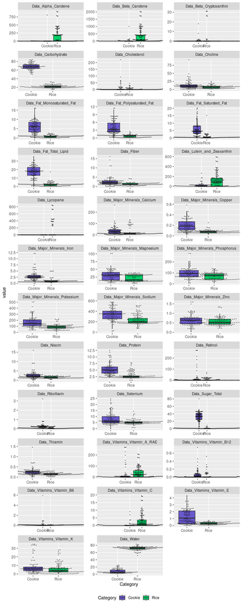

```r
df.long1 <- cleaned_data %>%
  pivot_longer(Data_Alpha_Carotene:Data_Vitamins_Vitamin_K, names_to = 'variable', values_to = 'value')

#ggplot(data = cleaned_data, aes(x = Category, y = Data_Alpha_Carotene, fill = Category)) +
#  geom_boxplot(outlier.shape = NA) +
#  scale_fill_manual(values=c("slateblue3", "springgreen3"))+
#  theme(legend.position="bottom") +
#  geom_beeswarm(cex=5, size=0.1)

ggplot(data = df.long1, aes(x = Category, y = value, fill = Category)) +
  geom_boxplot(outlier.shape = NA) +
  scale_fill_manual(values=c("slateblue3", "springgreen3"))+
  theme(legend.position="bottom") +
  geom_beeswarm(cex=3, size=0.1) +
  facet_wrap(facets = ~variable, scales = 'free', ncol=3)
```

```r
#ggplot(data = df.long1, aes(x = Category, y = value, fill = Category)) +
#  geom_boxplot(outlier.colour =  'red3', outlier.shape = 3, outlier.size = 0.5) +
#  scale_fill_manual(values=c("slateblue3", "springgreen3"))+
#  theme(legend.position="bottom") +
#  geom_beeswarm(cex=1)+
#  facet_wrap(facets = ~variable, scales = 'free', ncol=3)
```

## Категориальные переменные

1. Сделайте подходящие визуализации категориальных переменных. Обоснуйте, почему выбрали именно этот тип.

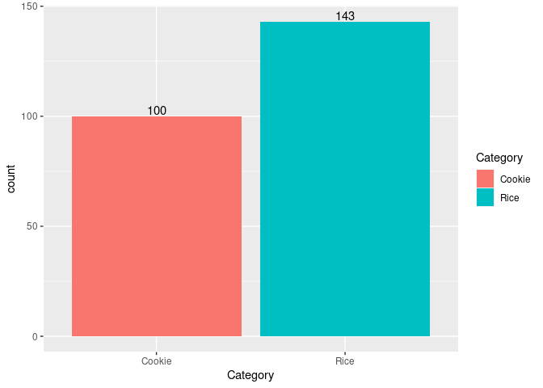

```r
ggplot(data=cleaned_data,  aes(x=Category, fill=Category)) +
  geom_bar()+
  geom_text(stat='count', aes(label=..count..), vjust = -0.2)
```

В данных всего одна категориальная переменная с 2мя уровнями, потому и была выбрана столбиковая диаграмма для визуализации.

# Статистические оценки

## Проверка на нормальность

1. Оцените каждую переменную на соответствие нормальному распределению с помощью теста Шапиро-Уилка. Какие из переменных являются нормальными и как как вы это поняли?

```r
cleaned_data %>%
  select(starts_with("Data_")) -> num_part_of_cd

do.call(rbind, lapply(num_part_of_cd, function(x) shapiro.test(x)[c("statistic", "p.value")]))
```

```
##                                statistic p.value
## Data_Alpha_Carotene            0.4979695 9.676071e-26
## Data_Beta_Carotene             0.554394  1.715896e-24
## Data_Beta_Cryptoxanthin        0.1884713 4.175524e-31
## Data_Carbohydrate              0.7790791 8.226354e-18
## Data_Cholesterol               0.2902534 1.484996e-29
## Data_Choline                   0.6824783 4.016347e-21
## Data_Fiber                     0.6148296 5.202927e-23
## Data_Lutein_and_Zeaxanthin     0.6985567 1.250007e-20
## Data_Lycopene                  0.341717  1.058249e-28
## Data_Niacin                    0.6130087 4.667352e-23
## Data_Protein                   0.8382668 3.300713e-15
## Data_Retinol                   0.3054584 2.620854e-29
## Data_Riboflavin                0.4014662 1.212901e-27
## Data_Selenium                  0.7552767 1.027989e-18
## Data_Sugar_Total               0.7512548 7.34277e-19
## Data_Thiamin                   0.699119  1.301707e-20
## Data_Water                     0.7405159 3.048579e-19
## Data_Fat_Monosaturated_Fat     0.7928399 2.954615e-17
## Data_Fat_Polysaturated_Fat     0.7651067 2.381111e-18
## Data_Fat_Saturated_Fat         0.6999729 1.384479e-20
## Data_Fat_Total_Lipid           0.8200375 4.490983e-16
## Data_Major_Minerals_Calcium    0.6861165 5.172792e-21
## Data_Major_Minerals_Copper     0.764165  2.194573e-18
## Data_Major_Minerals_Iron       0.7328306 1.652164e-19
## Data_Major_Minerals_Magnesium  0.8729268 2.387868e-13
## Data_Major_Minerals_Phosphorus 0.9096507 6.00984e-11
## Data_Major_Minerals_Potassium  0.8356289 2.449477e-15
## Data_Major_Minerals_Sodium     0.9453805 6.830264e-08
## Data_Major_Minerals_Zinc       0.9152223 1.575115e-10
## Data_Vitamins_Vitamin_A_RAE    0.6285073 1.191785e-22
## Data_Vitamins_Vitamin_B12      0.4683625 2.364644e-26
## Data_Vitamins_Vitamin_B6       0.1407899 8.855802e-32
## Data_Vitamins_Vitamin_C        0.5692384 3.831207e-24
## Data_Vitamins_Vitamin_E        0.7380033 2.49161e-19
## Data_Vitamins_Vitamin_K        0.7408719 3.13734e-19
```

Судя по результатам работы критерия Шапиро-Уилка в датасете нет ни одной числовой переменной, которая была бы распределена нормально (значение p.value << 0.05).

2. Постройте для каждой количественной переменной QQ-плот. Отличаются ли выводы от теста Шапиро-Уилка? Какой метод вы бы предпочли и почему?

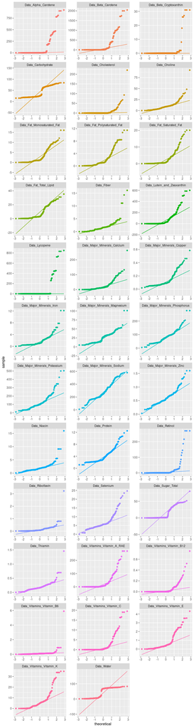

```r
#qq_plot <- ggplot(df.long1, aes(sample=value)) +
#  stat_qq() +
#  stat_qq_line()

ggplot(data = df.long1, aes(sample = value, color = variable)) +
  stat_qq_line()+
  stat_qq()+
  theme(legend.position="none") +
  facet_wrap(facets = ~variable, scales = 'free', ncol=3)
```

3. Ниже напишите, какие ещё методы проверки на нормальность вы знаете и какие у них есть ограничения.

**Напишите текст здесь** Для оценки нормальности распределения данных я скорее предпочёл бы не полагаться на какой-то единственный метод проверки, а учитывать результаты нескольких, т.е. чтобы оценка была интегральной. Но если вопрос ставить именно так, то я опирался бы в первую очередь на QQ-plot, нежели чем на тест Шапиро-Уилка, т.к. последний ведёт себя подобно другим статистическим тестам - чем больше выборка, тем с большей вероятностью он “поймает” отклонения от нормальности; чем меньше выборка, тем с меньшей вероятностью он обнаружит даже серьезные отклонения от нормальности, хотя мы заинтересованы в обратном. При большой выборке отклонения от нормальности не так страшны, а при маленькой тест все равно ничего не обнаружит. Т.к. идеально нормальных распределений в природе почти не существует, это значит, что при достаточно большой выборке тест Шапиро-Уилка практически всегда будет находить отклонения от нормальности (например QQ-plot для Data_Major_Minerals_Sodium выглядит вполне прилично). Все это делает его во многом малоинформативным при тестировании допущения о нормальности. Это же верно и для других тестов на нормальность (критерий Колмогорова-Смирнова, критерий Андерсона-Дарлинга и др.). Также графически можно оценить нормальность с помощью гистограммы (с наложением поверх функции плотности вероятности для нормального распределённых данных).

## Сравнение групп

1. Сравните группы (переменная **Category**) по каждой переменной (как количественной, так и категориальной). Для каждой переменной выберите нужный критерий и кратко обоснуйте его выбор в комментариях.

```r
rquery.t.test<-function(x, y, var.equal.p, graph = TRUE)
{
      var.equal.p<-signif(var.equal.p,1)

          if(graph) par(mfrow=c(2,2))
          # normality test
          shapiro.px<-normaTest(x, graph,
                                hist.title="X - Histogram",
                                qq.title="X - Normal Q-Q Plot")
          shapiro.py<-normaTest(y, graph,
                                hist.title="Y - Histogram",
                                qq.title="Y - Normal Q-Q Plot")
          if(shapiro.px < 0.05 | shapiro.py < 0.05){
              warning("x or y is not normally distributed!",
                      " Shapiro test p-value : ", shapiro.px,
                      " (for x) and ", shapiro.py, " (for y)",
                      " Levene's test p-value :", var.equal.p)
            }
   }
normaTest<-function(x, graph=TRUE,
                    hist.title="Histogram",
                    qq.title="Normal Q-Q Plot",...)
  {
  # Significance test
  #++++++++++++++++++++++
  shapiro.p<-signif(shapiro.test(x)$p.value,1)

  if(graph){
    # Plot : Visual inspection
    #++++++++++++++++
    h<-hist(x, col="lightblue", main=hist.title,
            xlab="Data values", ...)
    m<-round(mean(x),1)
    s<-round(sd(x),1)
    mtext(paste0("Mean : ", m, "; SD : ", s),
          side=3, cex=0.8)
    # add normal curve
    xfit<-seq(min(x),max(x),length=40)
    yfit<-dnorm(xfit,mean=mean(x),sd=sd(x))
    yfit <- yfit*diff(h$mids[1:2])*length(x)
    lines(xfit, yfit, col="red", lwd=2)
    # qq plot
    qqnorm(x, pch=19, frame.plot=FALSE,main=qq.title)
    qqline(x)
    mtext(paste0("Shapiro-Wilk, p-val : ", shapiro.p),
          side=3, cex=0.8)
  }
  return(shapiro.p)
}

sepfoo <- function(var1, var2) {

  cleaned_data %>%
    filter({{ var1 }} == "Cookie") %>%
    pull({{ var2 }}) -> x

  cleaned_data %>%
    filter({{ var1 }} == "Rice") %>%
    pull({{ var2 }}) -> y

  dat <- cleaned_data %>%
     select({{ var1 }}, {{ var2 }}) %>%
     mutate(var1 = {{ var1 }},
            var2 = {{ var2 }})

  var.equal.p = first(car::leveneTest(data = dat, var2 ~ var1)$`Pr(>F)`)

  rquery.t.test(x, y, var.equal.p)
}
```

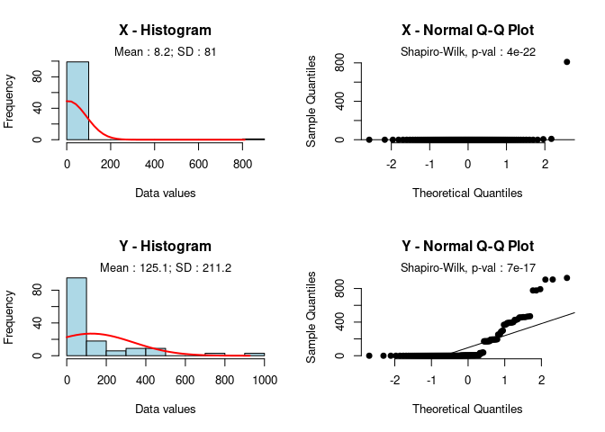

```r
sepfoo(Category, Data_Alpha_Carotene)
```

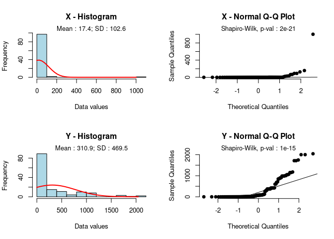

```r
sepfoo(Category, Data_Beta_Carotene)
```

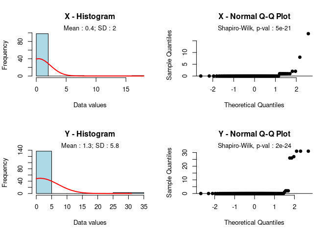

```r
sepfoo(Category, Data_Beta_Cryptoxanthin)
```

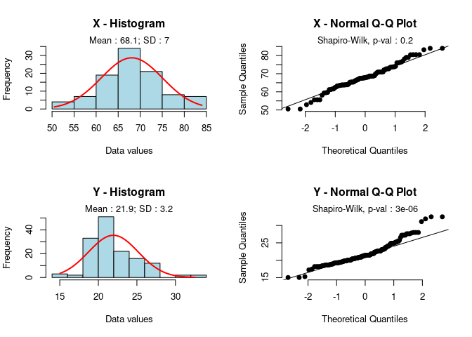

```r
sepfoo(Category, Data_Carbohydrate)
```

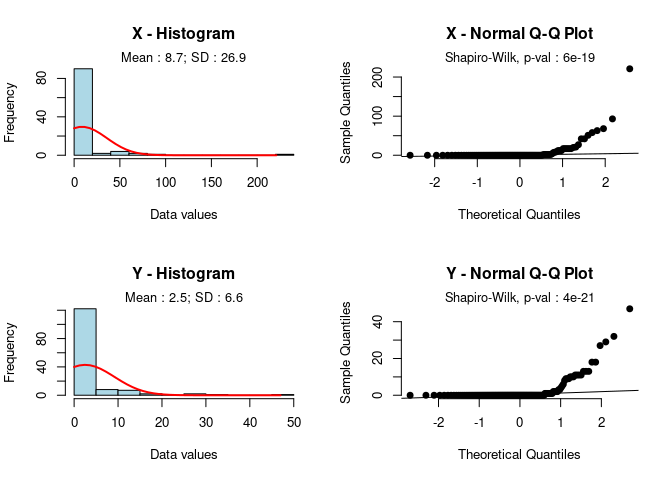

```r
sepfoo(Category, Data_Cholesterol)
```

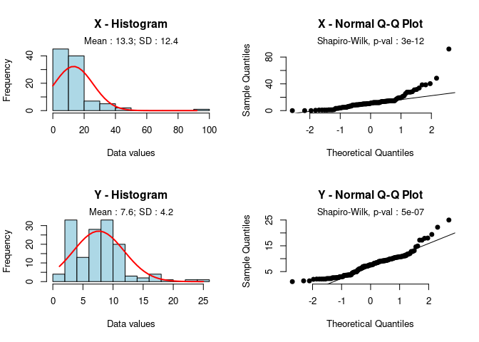

```r
sepfoo(Category, Data_Choline)
```

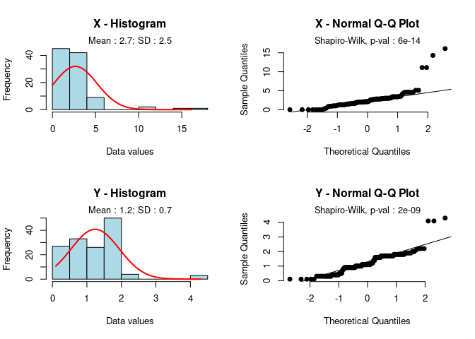

```r
sepfoo(Category, Data_Fiber)
```

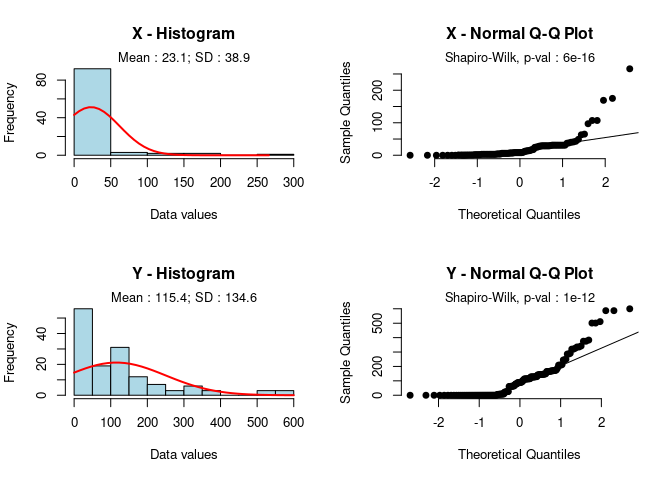

```r
sepfoo(Category, Data_Lutein_and_Zeaxanthin)
```

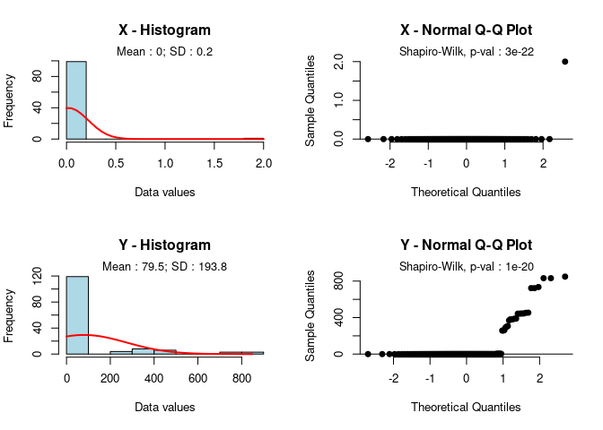

```r
sepfoo(Category, Data_Lycopene)
```

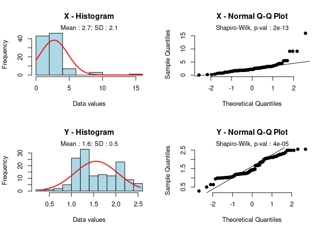

```r
sepfoo(Category, Data_Niacin)
```

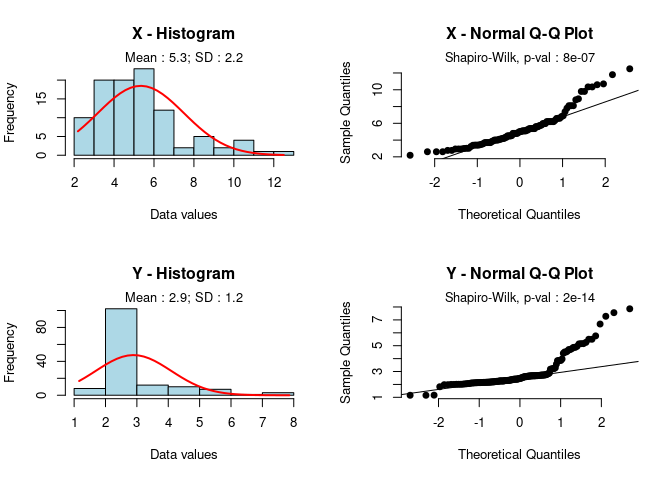

```r
sepfoo(Category, Data_Protein)
```

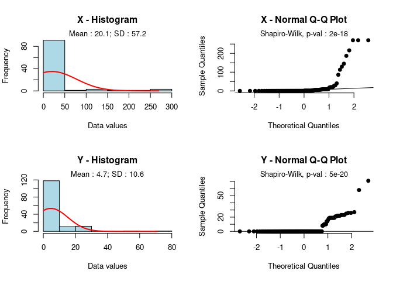

```r
sepfoo(Category, Data_Retinol)
```

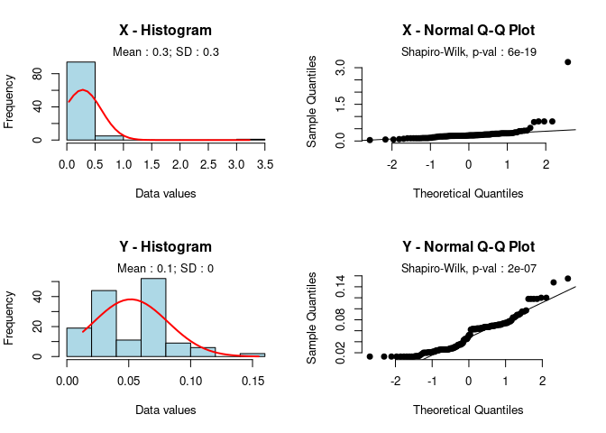

```r
sepfoo(Category, Data_Riboflavin)
```

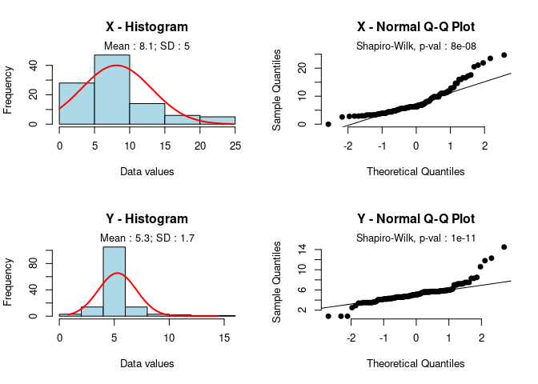

```r
sepfoo(Category, Data_Selenium)
```

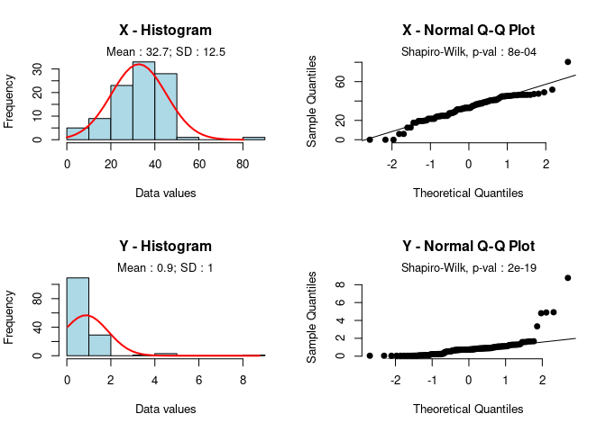

```r
sepfoo(Category, Data_Sugar_Total)
```

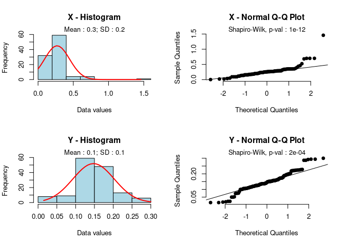

```r
sepfoo(Category, Data_Thiamin)
```

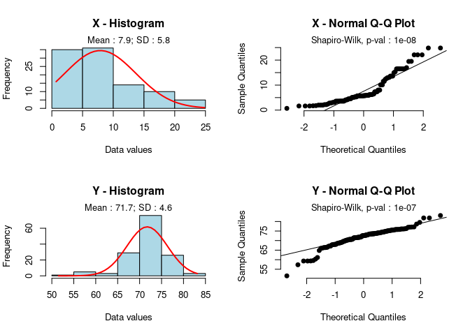

```r
sepfoo(Category, Data_Water)
```

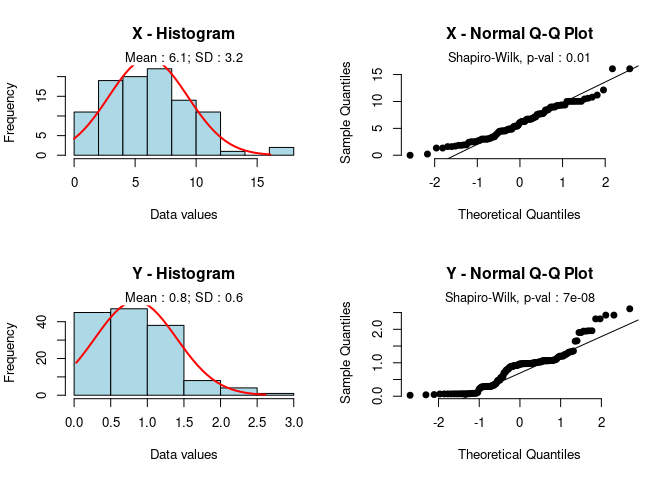

```r
sepfoo(Category, Data_Fat_Monosaturated_Fat)
```

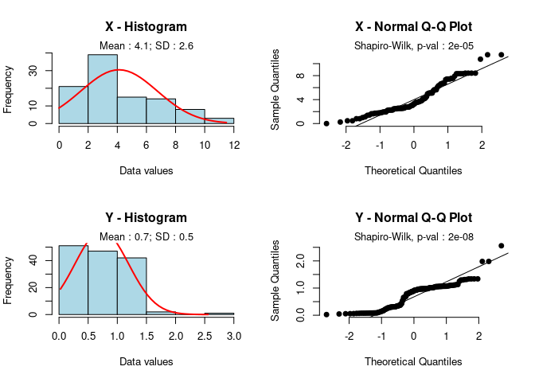

```r
sepfoo(Category, Data_Fat_Polysaturated_Fat)
```

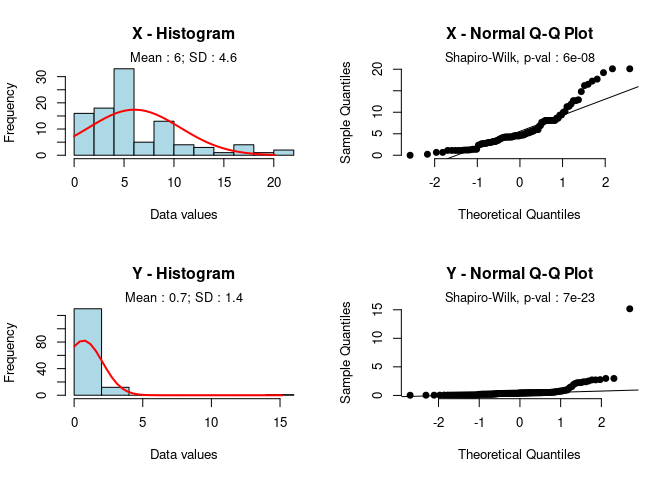

```r
sepfoo(Category, Data_Fat_Saturated_Fat)
```

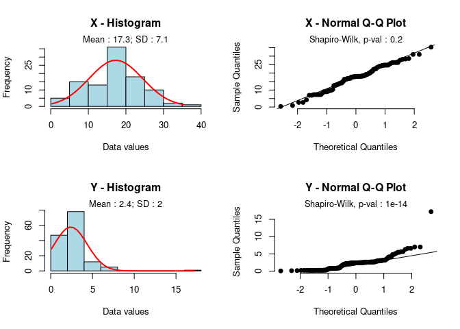

```r
sepfoo(Category, Data_Fat_Total_Lipid)
```

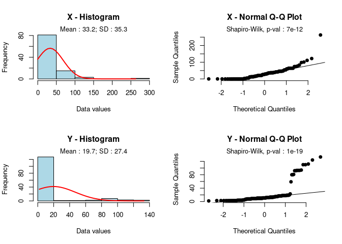

```r
sepfoo(Category, Data_Major_Minerals_Calcium)
```